# From microbes to multi-omics — Oulu 2026

University of Oulu · Sep 28–30, 2026

From microbes  
to multi-omics

Microbiome data science with **R/Bioconductor**  
Three days · 9:00–16:00 · lectures, demos & hands-on  
**Leo Lahti** · **Tuomas Borman** · **Anna Kaisanlahti**

[figure not shown]

[figure not shown]

[figure not shown]

[figure not shown]

[figure not shown]

[figure not shown]

## Why are we here?

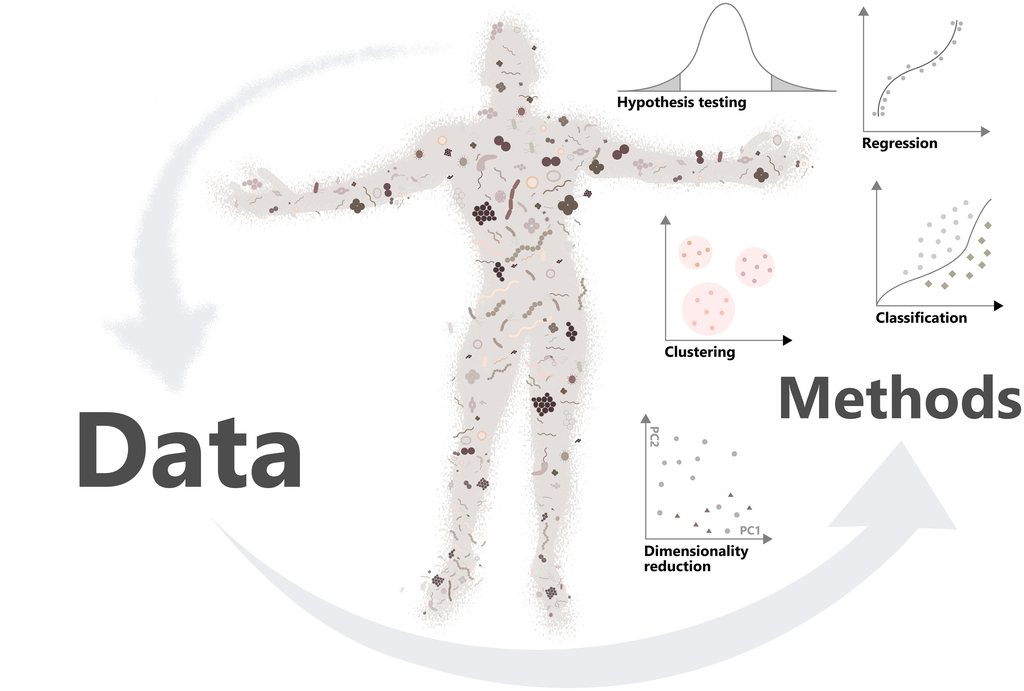

## What you will learn

🔁

Reproducible

Transparent workflows with R and Quarto

📦

Standardized

Shared data containers for single- and multi-omics

🧭

Independent

Navigate documentation & existing tools for new tasks

You don’t need to know everything —  
learn the ecosystem and how to navigate it.

## Three days at a glance

Day 1

Open data science

Reproducible workflows with R/Bioconductor and Quarto

Day 2

Single omics

Tabular data analysis & visualization

Day 3

Multi-omics

Multi-assay data integration

Each topic: **short lecture + demo**, then mostly **hands-on exercises** — help is always available and materials stay online after the course.

## Who’s who

Instructors

Leo Lahti  
Tuomas Borman

Coordinator

Anna Kaisanlahti

Organizers

HBS-DP, University of Oulu Graduate School

Computing

CSC cloud services

**For:** MSc students, PhD candidates, postdocs and researchers building skills in R programming omics analysis visualization reproducible reporting

## Materials & links

📘 **OMA book**  
https://bioconductor.org/books/release/OMA/

☁️ **CSC environment**  
https://noppe.rahtiapp.fi/

💬 **Questions**  
shared Google doc

[figure not shown]

## Code of Conduct

🤝

Sharing ideas, code, software and expertise

🧩

Collaboration

🌍

Diversity and inclusivity

💛

A kind and welcoming environment

Bioconductor CoC: https://bioconductor.github.io/bioc_coc_multilingual/

01

Open data science

Reproducible workflows with R/Bioconductor and Quarto

## Day 1 — Schedule

| Time | Activity |
| --- | --- |
| 9:00–10:00 | ☕ Coffee, welcome & practicalities |
| 10:00–11:00 | Introduction to CSC RStudio notebook |
| 11:00–12:00 | Lecture: open & reproducible workflows |
| 12:00–13:00 | 🍽️ Lunch break |
| 13:00–16:00 | Working with data containers and workflows |
| Evening | Informal course dinner (own cost) |

## Day 1 — Goals

- Principles of **open & reproducible** microbiome / omics analysis
- The **Bioconductor** ecosystem
- Why **standardized data containers** matter

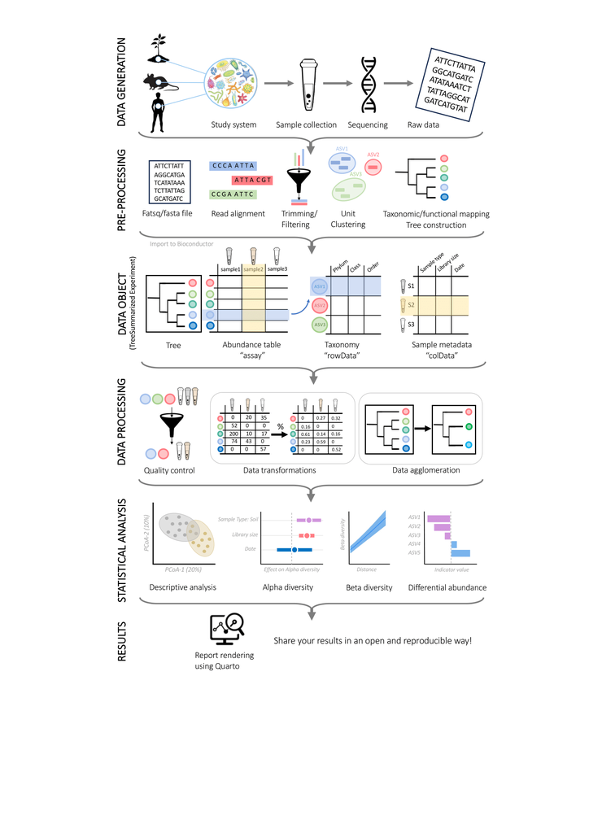

## Microbiome research

- **Microbiome:** the community of microbes and their genes in a habitat (e.g. human gut)
- Vital role in health & environment
- Data: sequencing profiles + additional molecular layers

[figure not shown]

## One container to hold it all

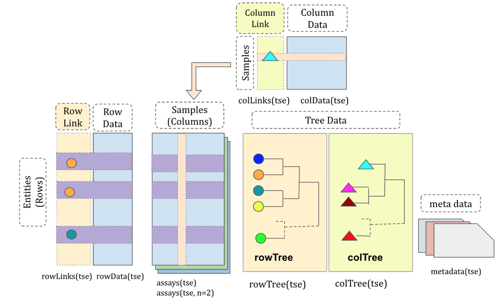

`TreeSummarizedExperiment` — assays, sample & feature data, trees in one object

## Hands-on

🖥️ Slides

[Data containers](https://microbiome.github.io/outreach/data_containers.html)

✍️ Exercises

[OMA Chapter 4, Exercises 1.2–1.7](https://bioconductor.org/books/release/OMA/pages/import.html)

## Day 1 — Take-home

Reproducible reporting

Analyses become verifiable and easier to reuse, review and extend

TreeSE

`TreeSummarizedExperiment` is the standard container for microbiome data

Bioconductor

Interoperable packages built on shared data infrastructure

## Feedback · Day 1

Tell us what worked — and what didn’t.

https://forms.gle/iEkoNdMVp9BUnyqNA

02

Single omics

Tabular data analysis & visualization

## Day 2 — Schedule

| Time | Activity |
| --- | --- |
| 9:00–10:00 | Lecture: analysis & visualization of tabular data (single omics) |
| 10:00–12:00 | Subsetting, transformations, and data summaries |
| 12:00–13:00 | 🍽️ Lunch break |
| 13:00–14:00 | Univariate data analysis and visualization |
| 14:00–16:00 | Multivariate data analysis and visualization |

## Feedback · Day 2

Tell us what worked — and what didn’t.

https://forms.gle/iEkoNdMVp9BUnyqNA

03

Multi-omics

Multi-assay data integration

## Day 3 — Schedule

| Time | Activity |
| --- | --- |
| 9:00–10:00 | Lecture: analysis & visualization of multi-assay data (multi-omics) |
| 10:00–12:00 | Multi-assay data analysis and visualization |
| 12:00–13:00 | 🍽️ Lunch break |
| 13:00–15:00 | Q&A and advanced techniques (time series, machine learning, simulation) |
| 15:00–16:00 | Summary and wrap-up |

## Linking the layers

`MultiAssayExperiment` links several omics layers measured on the same subjects.

microbiome metabolome transcriptome clinical

## Feedback · Day 3

Tell us what worked — and what didn’t.

https://forms.gle/iEkoNdMVp9BUnyqNA

## Thank you!

Keep learning with the OMA book: https://bioconductor.org/books/release/OMA/

[figure not shown]

[figure not shown]

[figure not shown]

[figure not shown]

[figure not shown]

[figure not shown]